# Probabilistic Programming in Python with PyMC3

## #ODSC East, Boston • May 5, 2017 • [@AustinRochford](https://twitter.com/AustinRochford)

## About Me

[figure not shown]

### [@AustinRochford](https://twitter.com/AustinRochford) • austinrochford.com • github.com/AustinRochford

### austin.rochford@gmail.com • arochford@monetate.com

### PyMC3 contributor • Principal Data Scientist at [Monetate Labs](http://www.monetate.com/)

## Probabilistic Programming

- Write a program to simulate the data generating process
- Language runtime/software library performs inference

[figure not shown]

### Data Science — inference enables storytelling

[figure not shown]

### Probabilistic Programming — storytelling enables inference

[figure not shown]

#### Enter: Bayes theorem

[figure not shown]

#### Benefits of probabilistic programming

- Model-agnostic inference algorithms
- Quantification of uncertainty
- *Incorporation of domain knowledge*
- *Modularity*

#### The Monty Hall Problem

[figure not shown]

Initially, we have no information about which door the prize is behind.

```python
import pymc3 as pm

with pm.Model() as monty_model:
    prize = pm.DiscreteUniform('prize', 0, 2)
```

If we choose door one:

|  | Monty can open |  |  |
| --- | --- | --- | --- |
| Prize behind | Door 1 | Door 2 | Door 3 |
| Door 1 | No | Yes | Yes |
| Door 2 | No | No | Yes |
| Door 2 | No | Yes | No |

```python
from theano import tensor as tt

with monty_model:
    p_open = pm.Deterministic('p_open',
                              tt.switch(tt.eq(prize, 0),
                                        # it is behind the first door
                                        np.array([0., 0.5, 0.5]),
                              tt.switch(tt.eq(prize, 1),
                                        # it is behind the second door
                                        np.array([0., 0., 1.]),
                                        # it is behind the third door
                                        np.array([0., 1., 0.]))))
```

Monty opened the third door, revealing a goat.

[figure not shown]

```python
with monty_model:
    opened = pm.Categorical('opened', p_open, observed=2)
```

Should we switch our choice of door?

```python
with monty_model:
    monty_trace = pm.sample(1000, init=None, random_seed=SEED)

monty_df = pm.trace_to_dataframe(monty_trace)
```

```
Assigned Metropolis to prize
```

```python
monty_df.head()
```

|  | prize | p_open__0 | p_open__1 | p_open__2 |
| --- | --- | --- | --- | --- |
| 0 | 1 | 0.0 | 0.0 | 1.0 |
| 1 | 0 | 0.0 | 0.5 | 0.5 |
| 2 | 0 | 0.0 | 0.5 | 0.5 |
| 3 | 0 | 0.0 | 0.5 | 0.5 |
| 4 | 0 | 0.0 | 0.5 | 0.5 |

```python
monty_df.prize.mean()
```

```
0.67300000000000004
```

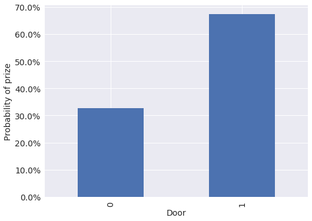

```python
fig
```

From the [PyMC3 documentation](http://pymc-devs.github.io/pymc3/):

> PyMC3 is a Python package for Bayesian statistical modeling and Probabilistic Machine Learning which focuses on advanced Markov chain Monte Carlo and variational fitting algorithms. Its flexibility and extensibility make it applicable to a large suite of problems.

### PyMC3 features

- Uses [Theano](http://deeplearning.net/software/theano/) as a computational backend
  - Automated differentiation, dynamic C compilation, GPU integration
- Implements Hamiltonian Monte Carlo and [No-U-Turn sampling](https://arxiv.org/abs/1111.4246)
- High-level GLM (`R`-like syntax) and Gaussian process specification
- Provides a framework for [operator variational inference](https://arxiv.org/abs/1610.09033)
  - Implements [ADVI](https://arxiv.org/abs/1603.00788) and [SVGD](https://arxiv.org/abs/1608.04471)

```python
HTML(mcmc_video)
```

[video not shown]

### Statistical workflow

1. Tell a story about how the data may have been generated
2. Encode that story as a probabilistic model
3. Perform inference
4. Check model diagnostics
5. Compare models
6. Iterate (`GOTO 1`)

#### Statistical LEGOs

[figure not shown]

## Case study: NBA foul calls

[figure not shown]

### Last two minute report

```python
nba_df.head()
```

|  | seconds_left | review_decision | away | home | score_away | score_home | disadvantaged_team | committing_team |
| --- | --- | --- | --- | --- | --- | --- | --- | --- |
| 0 | 111.0 | INC | UTA | POR | 104.0 | 113.0 | POR | UTA |
| 1 | 102.0 | CNC | UTA | POR | 104.0 | 113.0 | UTA | POR |
| 2 | 98.0 | CC | UTA | POR | 104.0 | 113.0 | POR | UTA |
| 3 | 64.0 | CNC | UTA | POR | 104.0 | 113.0 | UTA | POR |
| 4 | 62.0 | INC | UTA | POR | 104.0 | 113.0 | POR | UTA |

### Story

Close basketball games usually end with intentional fouls.

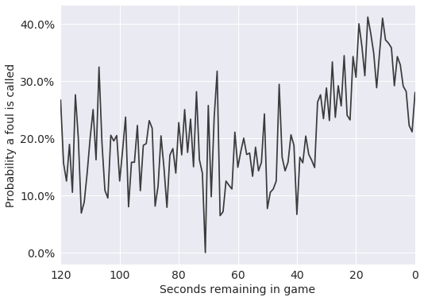

```python
fig
```

### Model

The foul call probability varies over time.

```python
seconds_left_ = theano.shared(seconds_left)

with pm.Model() as nba_model:
    β = pm.GaussianRandomWalk('β', tau=PRIOR_PREC, init=pm.Normal.dist(0., 10.),
                              shape=n_sec)
```

Transform logodds to probabilities, specify observation model.

```python
with nba_model:
    p = pm.math.sigmoid(β[seconds_left_])
    fc = pm.Bernoulli('fc', p, observed=foul_called)
```

### Inference

```python
nba_trace = sample_from_model(nba_model)
```

```
Auto-assigning NUTS sampler...
Initializing NUTS using ADVI...
Finished [100%]: Average Loss = 2,955.1
```

- Automatic sampler assignment (manually configurable)
- Automatic initialization of HMC/NUTS using ADVI

### Model diagnostics — posterior predictions

To sample from the posterior predictive distribution, we change the value of the Theano shared variable `seconds_left_`.

```python
pp_sec = np.arange(n_sec)
seconds_left_.set_value(pp_sec)

with nba_model:
    pp_nba_trace = pm.sample_ppc(nba_trace, N_PP_SAMPLES)
```

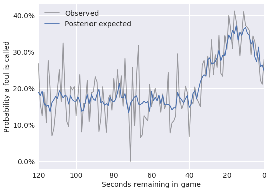

```python
fig
```

### Model diagnostics — sampling

> The folk theorem [of statistical computing] is this: *When you have computational problems, often there’s a problem with your model.*

— [Andrew Gelman](http://andrewgelman.com/2008/05/13/the_folk_theore/)

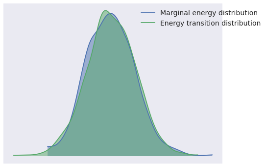

```python
pm.energyplot(nba_trace).legend(bbox_to_anchor=(0.6, 1));
```

### Model selection

PyMC3 can calculate:

- Deviance information criterion (DIC)
- Bayesian predictive information criterion (BPIC)
- **Widely applicable/Watanabe-Akaike information criterion (WAIC)**

```python
with nba_model:
    nba_waic = pm.waic(nba_trace)

print(nba_waic)
```

```
WAIC_r(WAIC=5834.1378643060807, WAIC_se=79.294920797807535, p_WAIC=16.602451)
```

### Story — take two

The trailing team has more incentive to foul than the leading team.

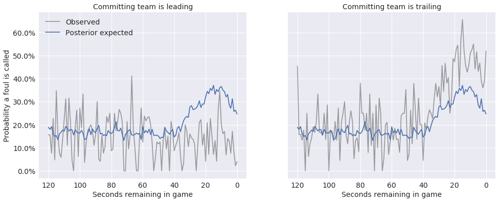

```python
fig
```

### Model and inference

There is a base rate at which fouls are called.

```python
with pm.Model() as trailing_model:
    α = pm.Normal('α', 0., 10.)
```

The trailing team is more likely to commit fouls as the game nears its end.

```python
seconds_left_.set_value(seconds_left)
committing_trailing_ = theano.shared(1. * (score_diff < 0))

with trailing_model:
    β = pm.GaussianRandomWalk('β', tau=PRIOR_PREC, init=pm.Normal.dist(0., 10.),
                              shape=n_sec)
    η = α + committing_trailing_ * β[seconds_left_]
```

```python
trailing_trace = sample_from_model(trailing_model, quiet=True)
```

### Model diagnostics — posterior prediction

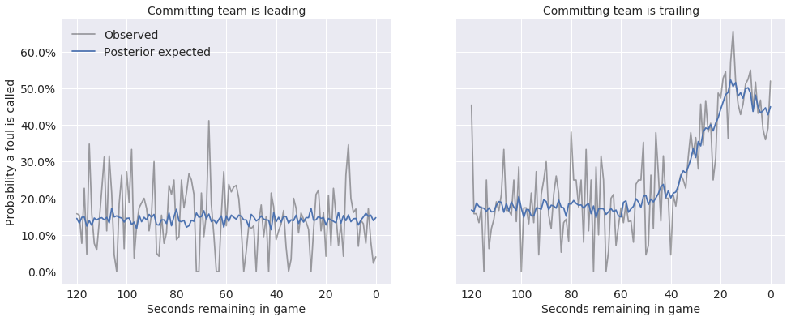

```python
fig
```

### Model selection

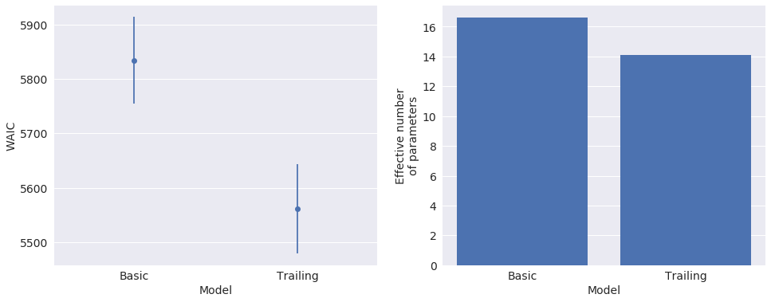

```python
fig
```

### Story — take three

Larger score differences incentivize the trailing team to foul sooner and more aggressively.

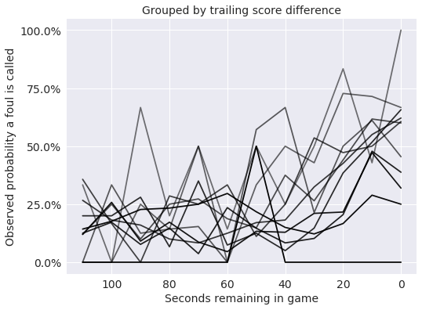

```python
fig
```

### Model and inference

There is a base rate at which fouls are called, and the trailing team is more likely to commit fouls as the game nears its end.

```python
seconds_left_.set_value(seconds_left)
committing_trailing_ = theano.shared(1. * (score_diff < 0))

with pm.Model() as diff_model:
    α = pm.Normal('α', 0., 10.)
    β = pm.GaussianRandomWalk('β', tau=PRIOR_PREC, init=pm.Normal.dist(0., 10.),
                              shape=n_sec)
```

The teams trailing by more points foul more agressively and sooner.

```python
score_diff_ = theano.shared(score_diff)

with diff_model:
    γ = pm.Normal('γ', 0., 10.)
    θ = pm.Normal('θ', 0., 10.)
    λ = pm.math.sigmoid(γ + θ * score_diff_)

    η = α + committing_trailing_ * λ * β[seconds_left_]
```

```python
diff_trace = sample_from_model(diff_model, quiet=True)
```

### Model diagnostics

#### Posterior predictive inference

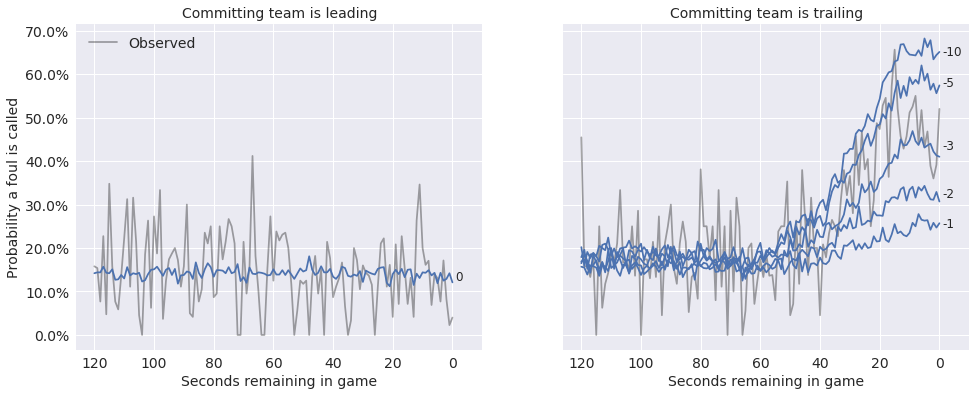

```python
fig
```

### Model selection

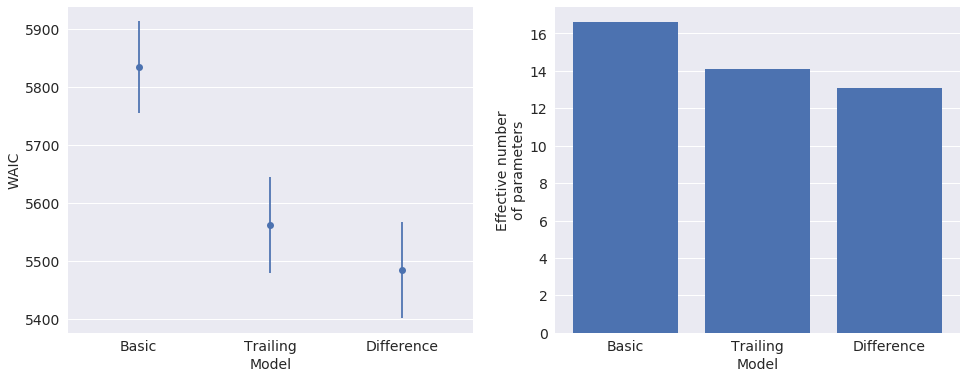

```python
fig
```

## Getting started with PyMC3

### Contributing

[figure not shown]

## Probabilistic Programming Ecosystem

| Probabilistic Programming System | Language | Discrete Variable Support | Automatic Differentiation/Hamiltonian Monte Carlo | Variational Inference |
| --- | --- | --- | --- | --- |
| [PyMC3](http://pymc-devs.github.io/pymc3/) | Python | Yes | Yes | Yes |
| [Stan](http://mc-stan.org/) | C++, R, Python, ... | No | Yes | Yes |
| [Edward](http://edwardlib.org/) | Python, ... | Yes | Yes | Yes |
| [BUGS](http://www.mrc-bsu.cam.ac.uk/software/bugs/) | Standalone program, R | Yes | No | No |
| JAGS | Standalone program, R | Yes | No | No |

## Thank you!

[figure not shown]

The Jupyter notebook used to generate these slides is available [here](https://gist.github.com/AustinRochford/9589e6ec6649954e09bda5e7641f75d4).